# MSDB Stereology analysis

Iris Oren & Anne-Laure Hemonnot

09 August 2017

The summary sheet of .xslx output files from steroinvestigator are saved as .csv.

All.csv files from all animals are stored in the /Data subdirectory from the project folder

Genotypes decoding spreadsheet with variables: |ID|Genotype| saved in /Data/Genotypes/GenotypeDat.csv (filename can be changed in Initialisation_Chunk, but the csv file should not be stored in the main Data directory)

User specifies User line - Region mapping in Initialisation_Chunk. More userlines can be added

Save the full dataframe

This is a Brain Slice showing (i) the staining and (ii) how we determined the junction between MS and DB

[output not shown]

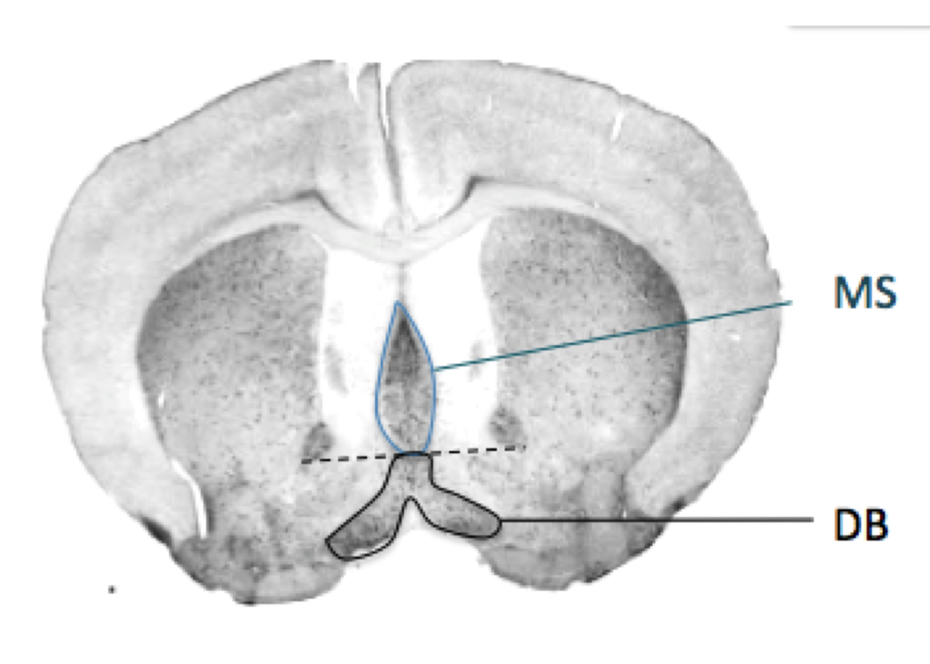

We visualize the useful data table

```
##    DataAll.EstPopUserDefThickness DataAll.Genotype DataAll.RegionVar
## 1                            3344   AD - Donepezil                MS
## 2                            5328   AD - Donepezil                DB
## 3                            2312   WT - Donepezil                MS
## 4                            3424   WT - Donepezil                DB
## 5                            2168   AD - Donepezil                MS
## 6                            2720   AD - Donepezil                DB
## 7                            1120   AD - Donepezil                DB
## 8                            2704   AD - Donepezil                MS
## 9                            2464   AD - Donepezil                MS
## 10                           3376   AD - Donepezil                DB
## 11                           2544   WT - Donepezil                MS
## 12                           1752   WT - Donepezil                DB
## 13                           2040   AD - Donepezil                MS
## 14                           1456   AD - Donepezil                DB
## 15                           3176   AD - Donepezil                DB
## 16                           2488   AD - Donepezil                MS
## 17                            344               WT                MS
## 18                           2256               WT                DB
## 19                           2720               WT                MS
## 20                           4592               WT                DB
## 21                           2336               WT                MS
## 22                           4640               WT                DB
```

Now we analyse the data, we want to know if there is a significant variation between AD treated and WT treated mice.

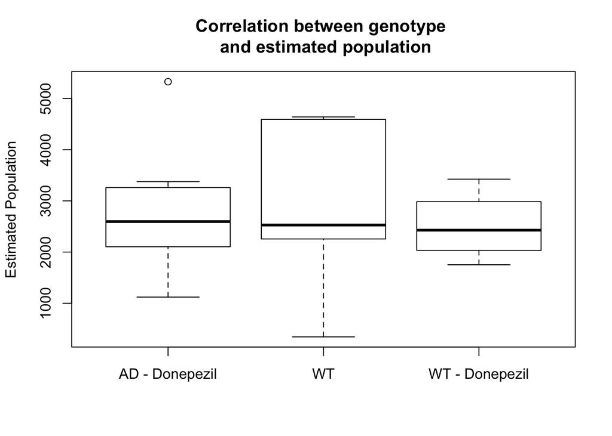

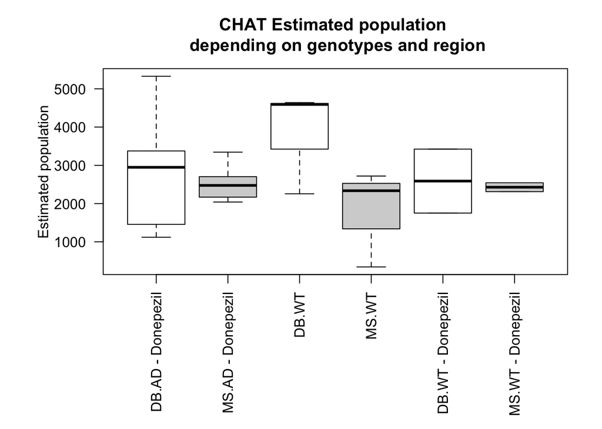

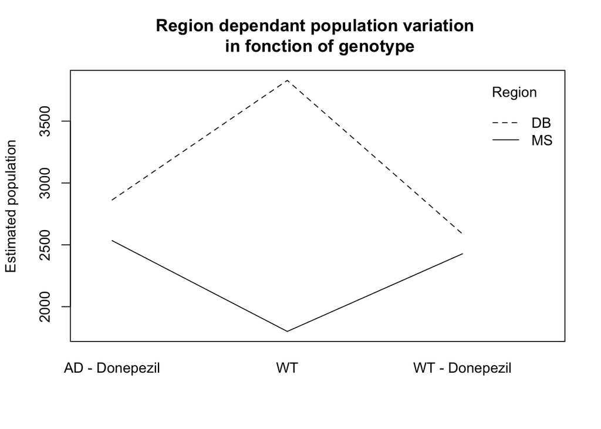

This representation shows that there is a more numerous ChAT interneurons population in the DB than the MS in WT mice whereas for treated mice (AD and WT) they seem to have a reduced DB population and increased MS population.

However there is an aberrant data on line 17 for an WT-MS value, I exclude it to visualize new graphs

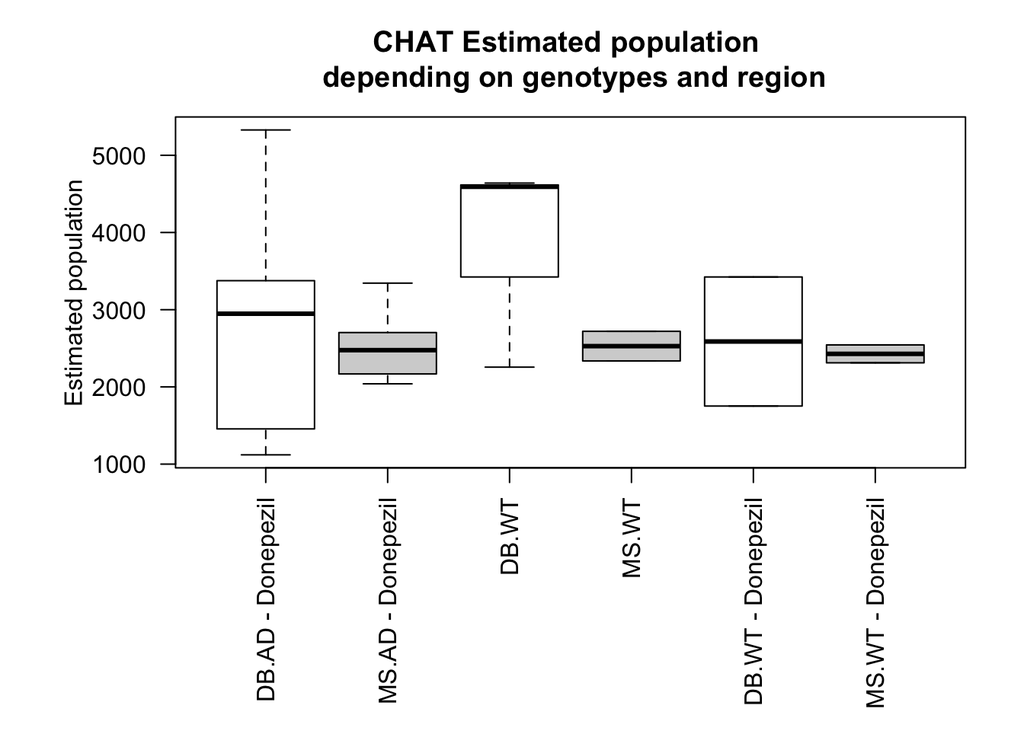

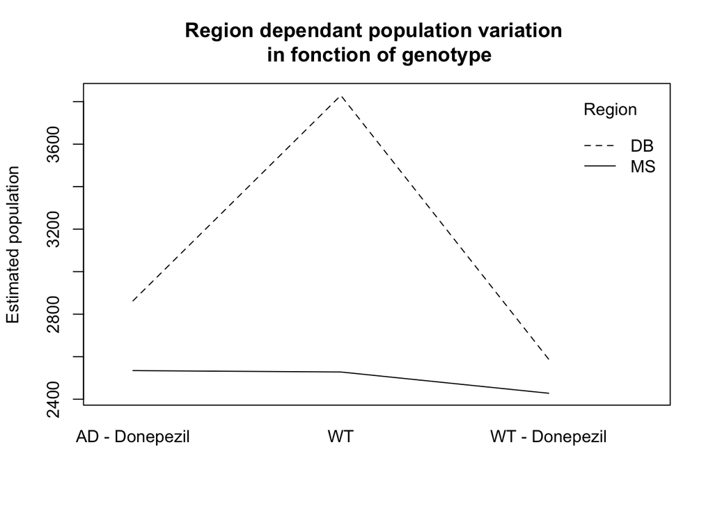

In conclusions:

CHAT + neuron total number is similar between the three groups if we look at graph#1

CHAT + neuron number varies depending on the region in WT sections with a higher number un DB vs MS

This regionalisation looks reduced by Donepezil but is not significant (I haven’t done any statistics on it but by seeing the error bars I am quite sure it will not be different)